# Notes for session 2

Ege Rubak (and Adrian Baddeley)

August 2022

## Parametric modelling of intensity

We can formulate a parametric model for the intensity and fit it to the point pattern data, using the `spatstat` function `ppm` (point process model).

In its simplest form, `ppm` fits a *Poisson point process model* to the point pattern data.

### Poisson point process

The *homogeneous Poisson process* with intensity $\lambda > 0$ in two-dimensional space is characterised by the following properties:

- for any region $B$, the random number $n(X \cap B)$ of points falling in $B$ follows a Poisson distribution;
- for any region $B$, the expected number of points falling in $B$ is $E[n(X \cap B)] = \lambda \, \mbox{area}(B)$;
- for any region $B$, given that $n(X \cap B) = n$, the $n$ points are independent and uniformly distributed inside $B$;
- for any *disjoint* regions $B_1,\ldots, B_m$, the numbers $n(X \cap B_1), \ldots, n(X \cap B_m)$ of points falling in each region are independent random variables.

Here are some realisations of the homogeneous Poisson process with intensity 100 (points per unit area):

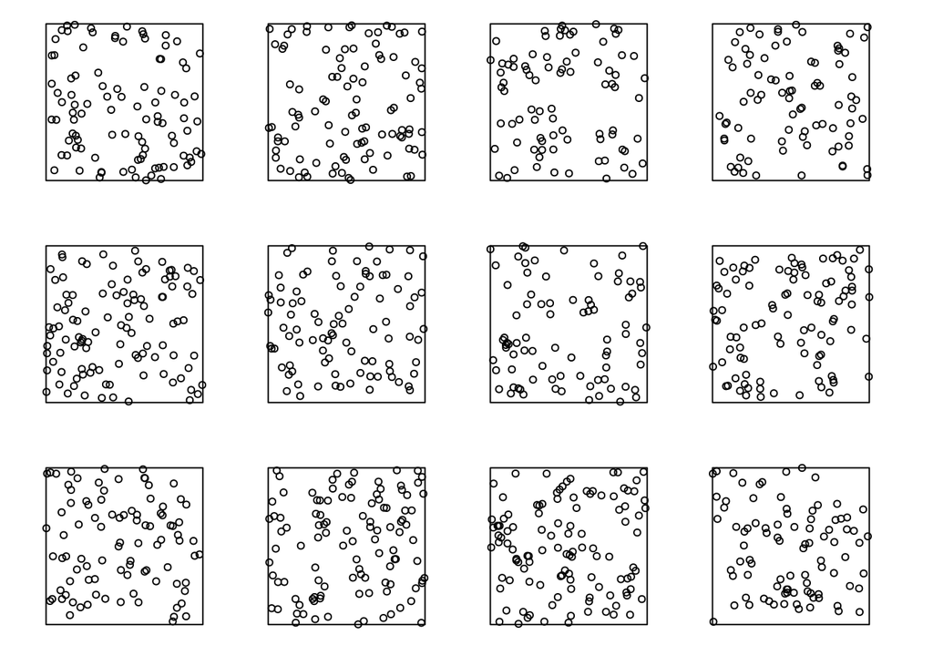

```r
plot(rpoispp(100, nsim=12), main="", main.panel="")
```

The *inhomogeneous* Poisson process with intensity *function* $\lambda(u)$ is characterised by the following properties:

- for any region $B$, the random number $n(X \cap B)$ of points falling in $B$ follows a Poisson distribution;
- for any region $B$, the expected number of points falling in $B$ is
  $$E[n(X \cap B)] = \int_B \lambda(u) \, {\rm d}u;$$
- for any region $B$, given that $n(X \cap B) = n$, the $n$ points are independent and *identically* distributed inside $B$ with probability density $f(u)= \lambda(u)/\Lambda$, where $\Lambda = \int_B \lambda(u) \, {\rm d}u$;
- for any *disjoint* regions $B_1,\ldots, B_m$, the numbers $n(X \cap B_1), \ldots, n(X \cap B_m)$ of points falling in each region are independent random variables.

Here are some realisations of the inhomogeneous Poisson process with intensity function $\lambda((x,y)) = 100 x$ on the unit square $[0,1]^2$ (why is this important?):

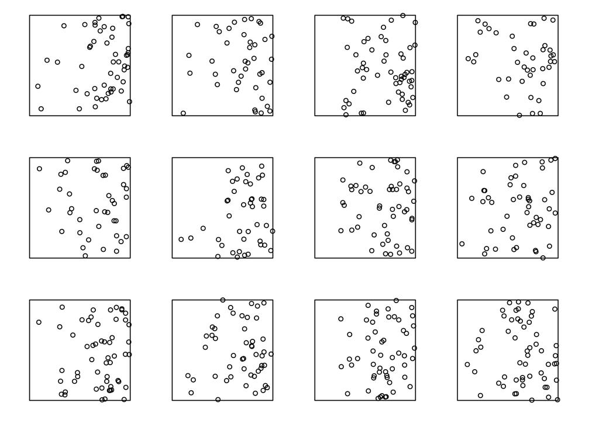

```r
lam <- function(x,y) { 100 * x}
plot(rpoispp(lam, nsim=12), main="", main.panel="")
```

### Loglinear model for intensity

`ppm` can fit a *Poisson point process model* to the point pattern data by maximum likelihood.

A Poisson point process is completely specified by its intensity function. So the procedure for formulating a Poisson model is simply to write a mathematical expression for the intensity function.

In `ppm` the intensity is assumed to be a **loglinear** function of the **parameters**. That is,
$$\log\lambda(u) = \beta_1 Z_1(u) +
\ldots + \beta_p Z_p(u)$$
where $\beta_1, \ldots, \beta_p$ are parameters to be estimated, and $Z_1, \ldots, Z_p$ are spatial covariates.

To fit this model to a point pattern dataset `X`, we type

```r
ppm(X ~ Z1 + Z2 + .. Zp)
```

where `Z1, Z2, ..., Zp` are pixel images or functions.

Important notes:

1. The model is expressed in terms of the **log** of the intensity.
2. The covariates $Z_1(u), \ldots, Z_p(u)$ (called the “canonical covariates”) can be anything; they are not necessarily the same as the original variables that we were given; they could be transformations and combinations of the original variables.

### Fit by maximum likelihood

The Poisson process with intensity function $\lambda_\theta(u)$, controlled by a parameter vector $\theta$, has log-likelihood
$$\log L(\theta) = \sum_{i=1}^n \log \lambda_\theta(x_i)
- \int_W \lambda_\theta(u) \, {\rm d} u.$$
The value of $\theta$ which maximises $\log L(\theta)$ is taken as the parameter estimate $\hat\theta$.

From $\hat\theta$ we can compute the fitted intensity $\hat\lambda(u) = \lambda_{\hat\theta}(u)$ and hence we can generate simulated realisations.

Using the likelihood we are able to compute confidence intervals, perform analysis of deviance, conduct hypothesis tests, etc.

*Example*: Murchison gold data

Using the Murchison data from before,

```r
X <- murchison$gold
L <- murchison$faults
X <- rescale(X, 1000, "km")
L <- rescale(L, 1000, "km")
D <- distfun(L)
fit <- ppm(X ~ D)
```

The formula implies that the model is
$$\log\lambda(u) = \beta_0 + \beta_1 D(u)$$
where $D(u)$ is the distance covariate (distance from location $u$ to nearest geological fault) and $\beta_0, \beta_1$ are the regression coefficients. In other words, the model says that the intensity of gold deposits is an exponentially decreasing function of distance from the nearest fault.

The result of `ppm` is a fitted model object of class `"ppm"`. There are many methods for this class:

```r
fit
```

```
## Nonstationary Poisson process
##
## Log intensity:  ~D
##
## Fitted trend coefficients:
## (Intercept)           D
##  -4.3412775  -0.2607664
##
##               Estimate       S.E.    CI95.lo    CI95.hi Ztest      Zval
## (Intercept) -4.3412775 0.08556260 -4.5089771 -4.1735779   *** -50.73802
## D           -0.2607664 0.02018789 -0.3003339 -0.2211988   *** -12.91697
```

```r
coef(fit)
```

```
## (Intercept)           D
##  -4.3412775  -0.2607664
```

```r
confint(fit)
```

```
##                  2.5 %     97.5 %
## (Intercept) -4.5089771 -4.1735779
## D           -0.3003339 -0.2211988
```

```r
anova(fit, test="Chi")
```

```
## Analysis of Deviance Table
## Terms added sequentially (first to last)
##
##      Df Deviance Npar  Pr(>Chi)
## NULL                1
## D     1   590.92    2 < 2.2e-16 ***
## ---
## Signif. codes:  0 '***' 0.001 '**' 0.01 '*' 0.05 '.' 0.1 ' ' 1
```

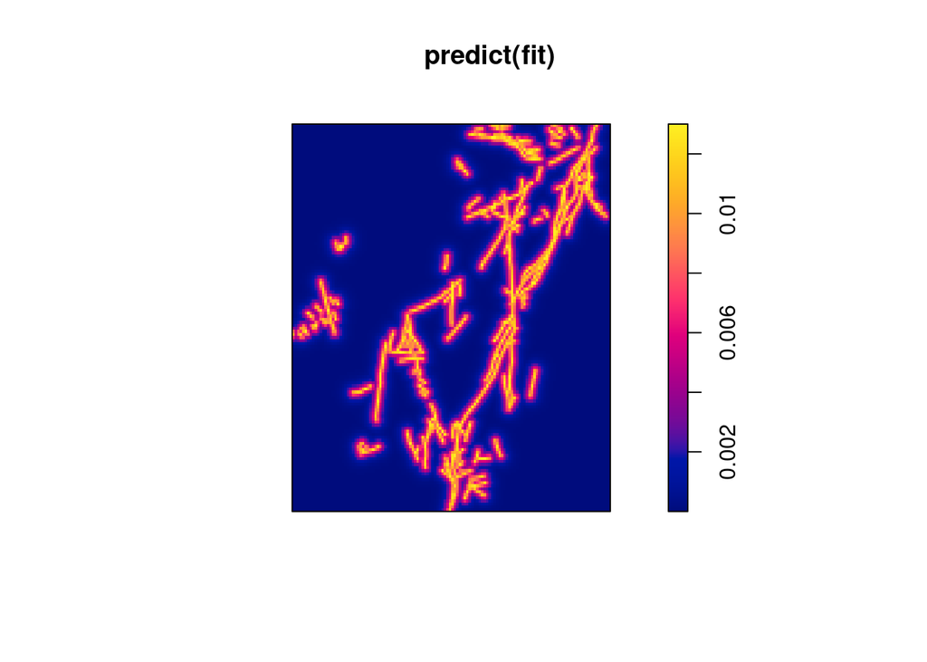

```r
plot(predict(fit))
```

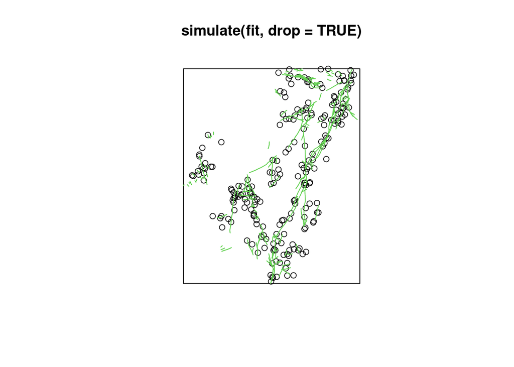

```r
plot(simulate(fit, drop=TRUE))
plot(L, add=TRUE, col=3)
```

To visualise the intensity of the model as a function of one of the covariates, we can use the command `effectfun`:

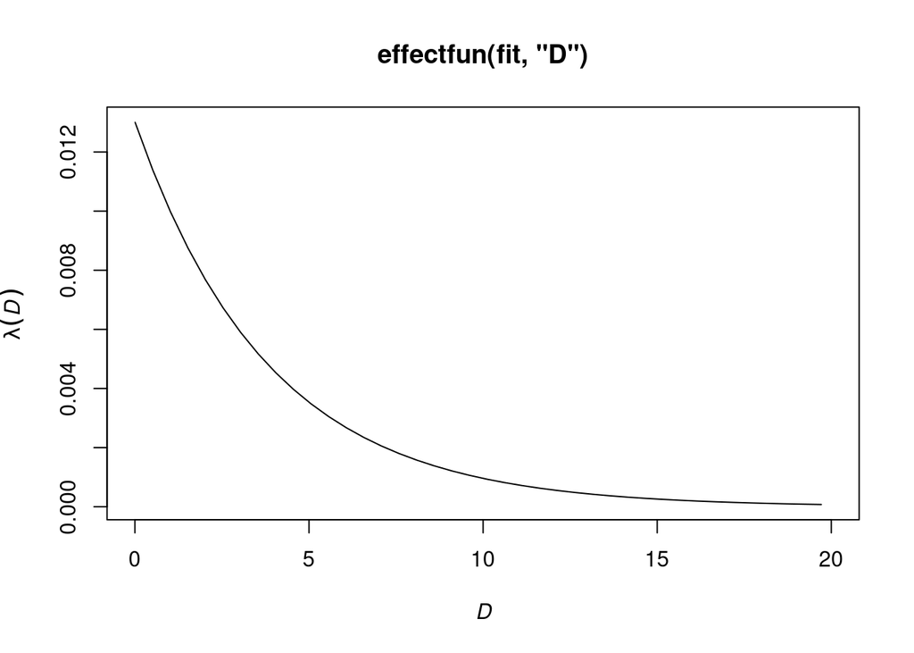

```r
plot(effectfun(fit, "D"), xlim=c(0, 20))
```

### Intensity depending on marks

In a *multi-type* point pattern the points have marks which are categorical values:

```r
mucosa
```

```
## Marked planar point pattern: 965 points
## Multitype, with levels = ECL, other
## window: rectangle = [0, 1] x [0, 0.81] units
```

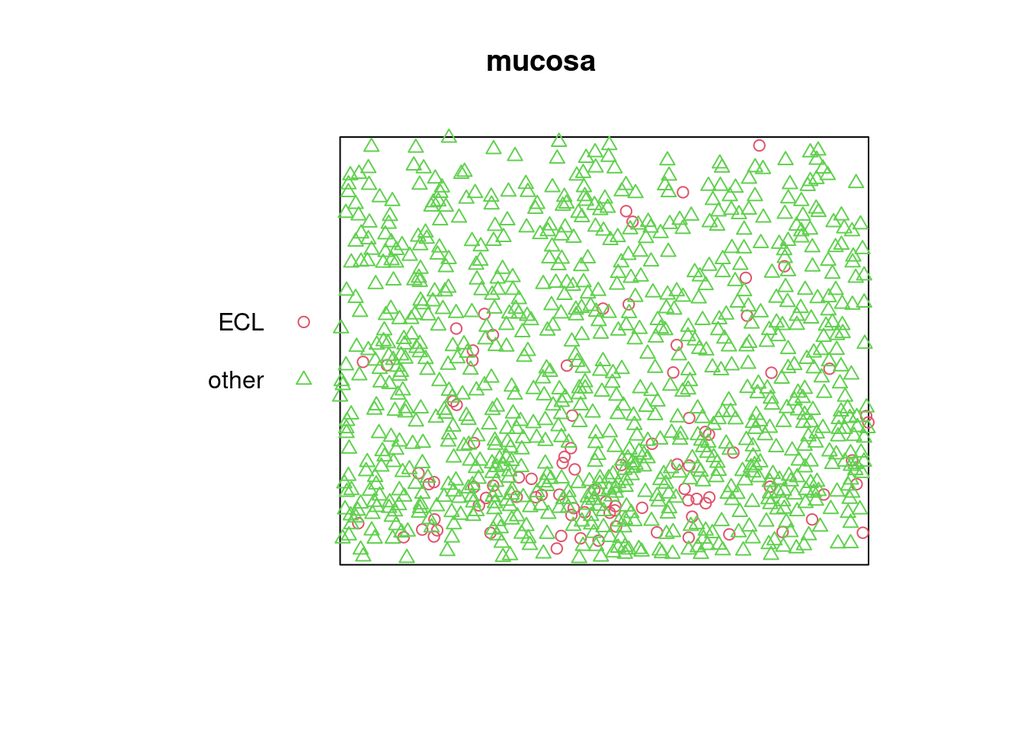

```r
plot(mucosa, cols=c(2,3))
```

We can fit a Poisson model in which the intensity depends on the type of point, using the variable name `marks` in the model formula.

```r
model0 <- ppm(mucosa ~ marks)
model0
```

```
## Stationary multitype Poisson process
##
## Possible marks: 'ECL' and 'other'
##
## Log intensity:  ~marks
##
## Intensities:
##   beta_ECL beta_other
##   109.8765  1081.4815
##
##             Estimate      S.E.  CI95.lo  CI95.hi Ztest     Zval
## (Intercept) 4.699357 0.1059998 4.491602 4.907113   *** 44.33365
## marksother  2.286730 0.1112542 2.068675 2.504784   *** 20.55409
```

```r
coef(model0)
```

```
## (Intercept)  marksother
##    4.699357    2.286730
```

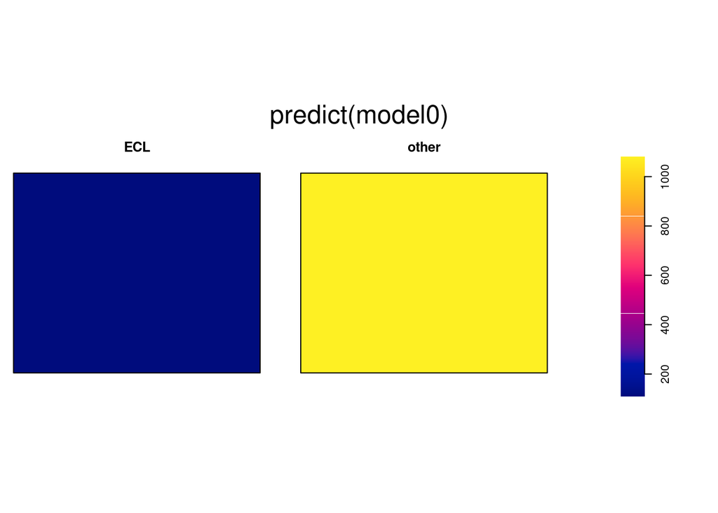

```r
plot(predict(model0), equal.ribbon=TRUE)
```

In the formula, the `marks` variable is a categorical variable. The effect of the model formula `mucosa ~ marks` is to estimate a different intensity for each level, that is, a different intensity for each type of point. The model formula `mucosa ~ marks` is equivalent to saying that the intensity of the points of type $i$ is
$$\lambda_i(u) = \alpha_i$$
for each $i = 1, 2, \ldots$ where $\alpha_1, \alpha_2, \ldots$ are the different constant intensities to be estimated. The actual printed output will depend on the convention for handling *“contrasts”* in linear models.

The `marks` variable can be combined with other explanatory variables (names `x` and `y` refer to the cartesian coordinates):

```r
model1 <- ppm(mucosa ~ marks + y)
model1
```

```
## Nonstationary multitype Poisson process
##
## Possible marks: 'ECL' and 'other'
##
## Log intensity:  ~marks + y
##
## Fitted trend coefficients:
## (Intercept)  marksother           y
##    5.131273    2.286730   -1.156055
##
##              Estimate      S.E.   CI95.lo    CI95.hi Ztest      Zval
## (Intercept)  5.131273 0.1164479  4.903039  5.3595066   *** 44.064966
## marksother   2.286730 0.1112542  2.068675  2.5047840   *** 20.554089
## y           -1.156055 0.1406821 -1.431787 -0.8803236   *** -8.217504
```

```r
coef(model1)
```

```
## (Intercept)  marksother           y
##    5.131273    2.286730   -1.156055
```

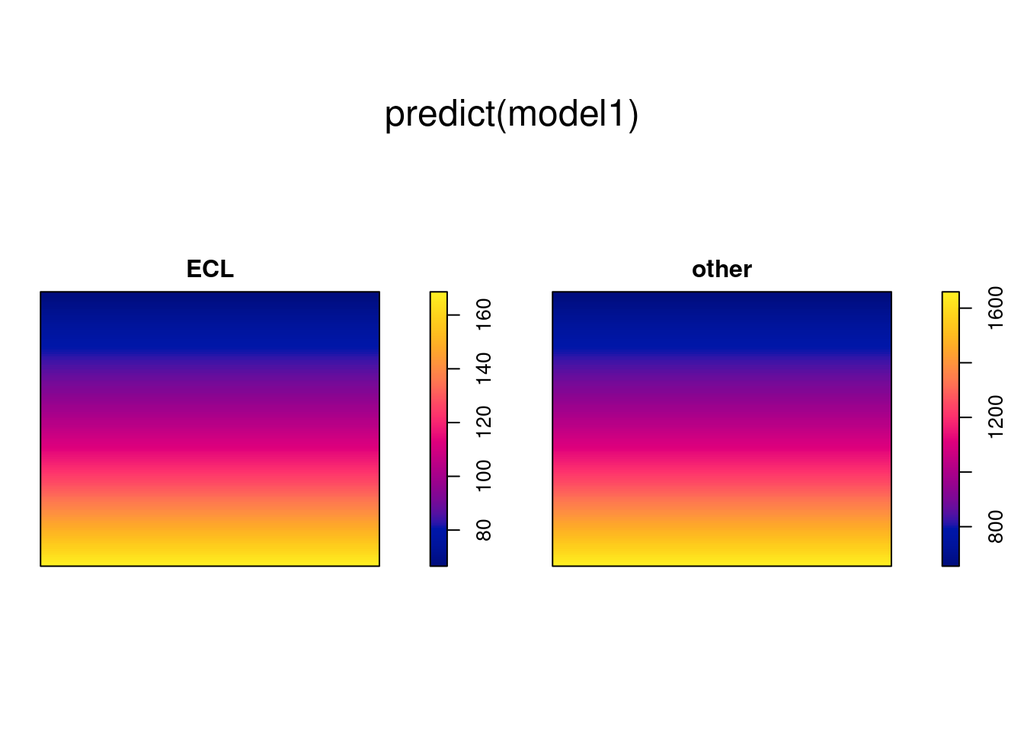

```r
plot(predict(model1))
```

The model formula `~marks + y` states that
$$\log \lambda_i((x,y)) = \gamma_i + \beta y$$
where $\gamma_1, \gamma_2, \ldots$ and $\beta$ are parameters. That is, the dependence on the $y$ coordinate has the same “slope” coefficient $\beta$ for each type of point, but different types of points have different abundance overall.

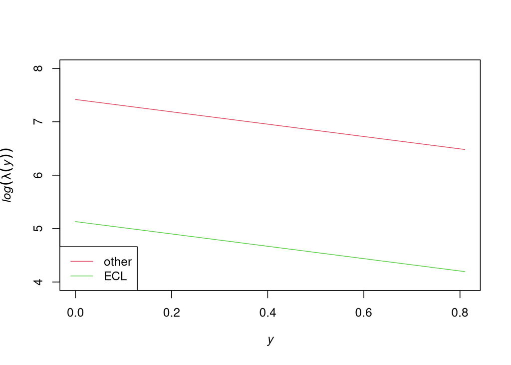

```r
plot(effectfun(model1, "y", marks="other"), log(.y) ~ .x, ylim=c(4,8), col=2, main="")
plot(effectfun(model1, "y", marks="ECL"), add=TRUE, col=3, log(.y) ~ .x)
legend("bottomleft", lwd=c(1,1), col=c(2,3), legend=c("other", "ECL"))
```

```r
model2 <- ppm(mucosa ~ marks * y)
model2
```

```
## Nonstationary multitype Poisson process
##
## Possible marks: 'ECL' and 'other'
##
## Log intensity:  ~marks * y
##
## Fitted trend coefficients:
##  (Intercept)   marksother            y marksother:y
##     5.884603     1.452251    -3.862202     2.938790
##
##               Estimate      S.E.   CI95.lo   CI95.hi Ztest      Zval
## (Intercept)   5.884603 0.1635842  5.563984  6.205222   *** 35.972936
## marksother    1.452251 0.1749458  1.109364  1.795139   ***  8.301149
## y            -3.862202 0.5616953 -4.963104 -2.761299   *** -6.875973
## marksother:y  2.938790 0.5804890  1.801053  4.076528   ***  5.062611
```

```r
coef(model2)
```

```
##  (Intercept)   marksother            y marksother:y
##     5.884603     1.452251    -3.862202     2.938790
```

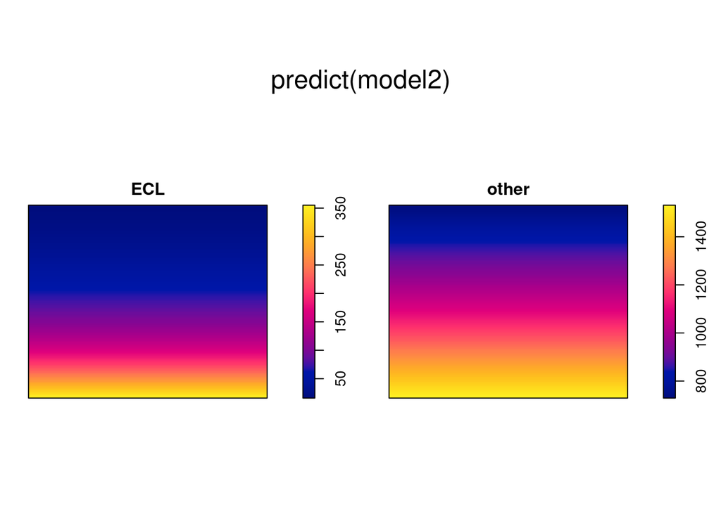

```r
plot(predict(model2))
```

The model formula `~marks * y` states that
$$\log \lambda_i((x,y)) = \gamma_i + \beta_i y$$
where $\gamma_1, \gamma_2, \ldots$ and $\beta_1,\beta_2, \ldots$ are parameters. The intensity may depend on the $y$ coordinate in a completely different way for different types of points.

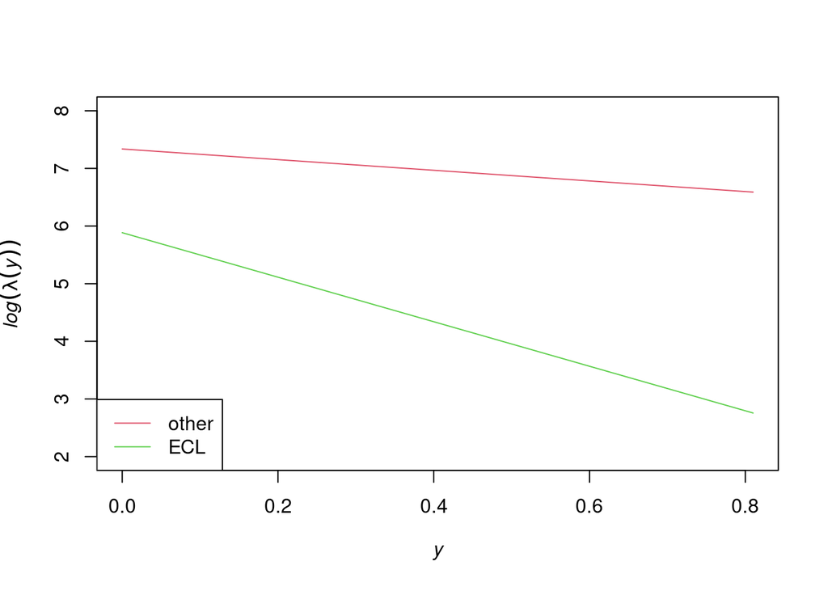

```r
plot(effectfun(model2, "y", marks="other"), log(.y) ~ .x, col=2, ylim=c(2,8), main="")
plot(effectfun(model2, "y", marks="ECL"), add=TRUE, col=3, log(.y) ~ .x)
legend("bottomleft", lwd=c(1,1), col=c(2,3), legend=c("other", "ECL"))
```

### Parametric estimation of spatially-varying probability

When we have fitted a point process model to a multi-type point pattern, we can compute ratios of the intensities of different types. This is automated in *relrisk.ppm*:

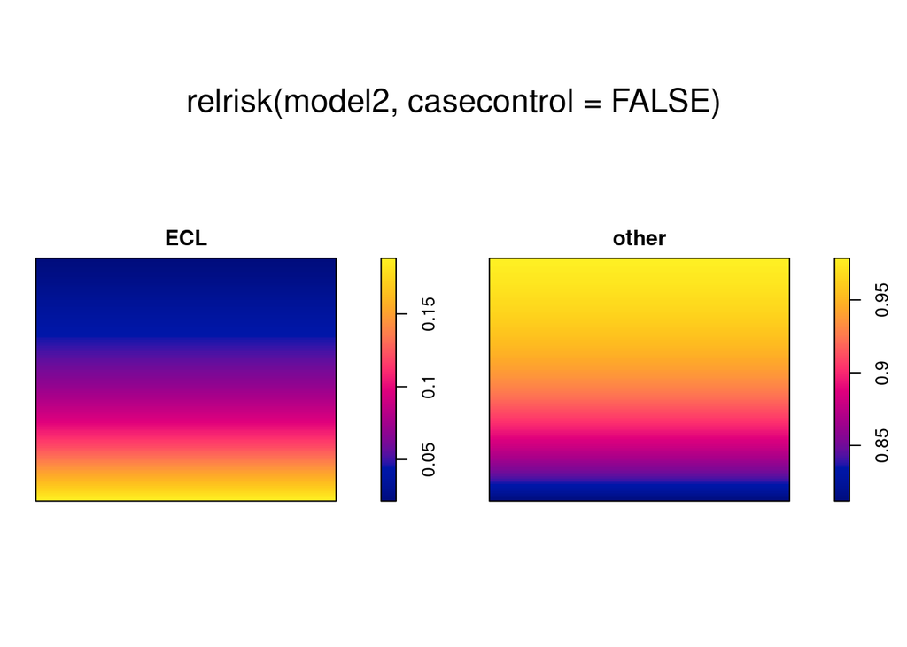

```r
plot(relrisk(model2, casecontrol=FALSE))
```

### Parametric test for segregation

One way to test for segregation is to compare two models, with the null model stating that there is no segregation:

```r
nullmodel <- ppm(mucosa ~ marks + polynom(x, y, 2))
altmodel <- ppm(mucosa ~ marks * polynom(x, y, 2))
anova(nullmodel, altmodel, test="Chi")
```

```
## Analysis of Deviance Table
##
## Model 1: ~marks + (x + y + I(x^2) + I(x * y) + I(y^2))    Poisson
## Model 2: ~marks * (x + y + I(x^2) + I(x * y) + I(y^2))    Poisson
##   Npar Df Deviance  Pr(>Chi)
## 1    7
## 2   12  5   44.834 1.568e-08 ***
## ---
## Signif. codes:  0 '***' 0.001 '**' 0.01 '*' 0.05 '.' 0.1 ' ' 1
```